# Hydrated or Lowdrated?

Are my current water and other beverage consumption habits in line with my goals?

Alexander Fine - afin858

14-05-2025

## Introduction

Once again, I seek insight into my (primarily) water-drinking habit, on the eternal quest to hit the famed 2l per day target. Because we are budding data analysts, merely assessing the 2l == TRUE question is surely not interesting enough for our purposes, and so we delve even deeper into the big question: Am I **Hydrated** or **Lowdrated**?

If you are interested in seeing the data collected (by me, for me, over the course of 4 days in total), [feel free to check out my Google Form here](https://docs.google.com/forms/d/e/1FAIpQLScT9R537mARgyUY7M-9bwX5IsVTCrg83M6Tsb1YjjH2wLQA7Q/viewform?usp=sharing) to see my “drinking events”.

Scroll down to have some mind-bogglingly mundane facts revealed to you!

## Part 1: A Thirst for Thirst Knowledge

I want to gain an understanding of what my drinking behaviour is like. How thirsty am I? The amount I drink per “drinking event” is of interest to me. I define three levels for small, medium, and large quantity of liquid drank as Sippy, Drinky, and Gulpy, respectively.

As if these technical terms are not self-explanatory, I formalise my definition of Sippy as 100ml or less, Drinky as under 250ml or less, and Gulpy as 5000ml or less. I (very wisely, in my estimation) created an upper limit here, as if I drank more than 5l in one sitting, I would surely not be here writing this report.

Having manipulated my data to create these new categories, I am able to neatly present the findings:

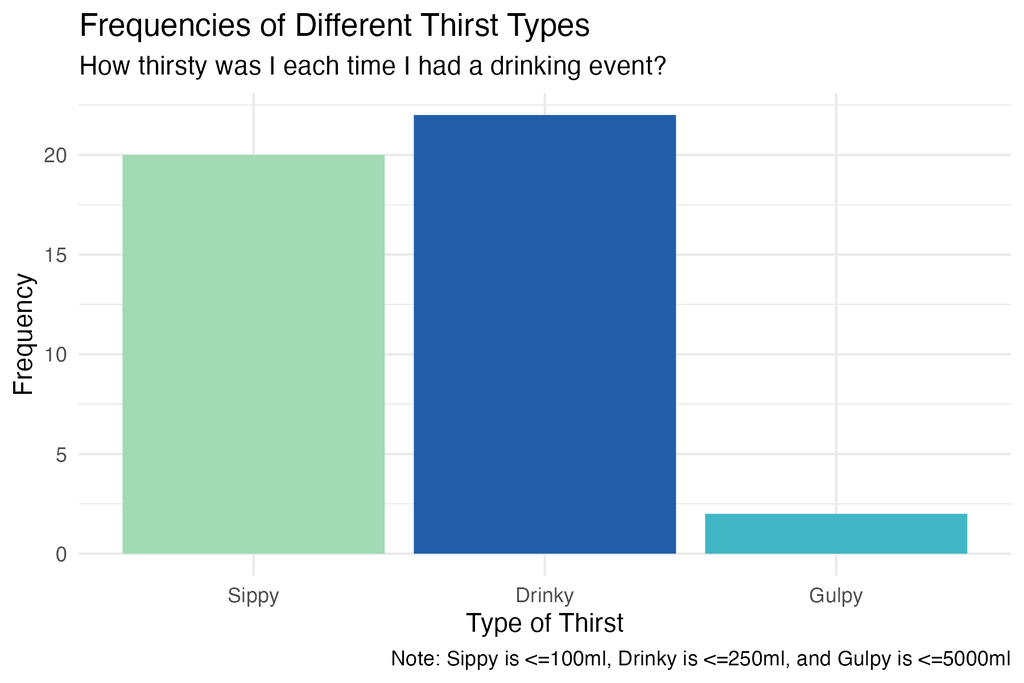

Plot 1: Visualisation of what types of thirst I successfully quenched and how frequently

## Part 2: What Are These “Drinking Events” I Speak Of?

It is not obvious to me from the above frequency plot what my drinking events look like. Did I have 2 moments of drinking 4995ml, nearing almost certain death via water poisoning at my completely arbitrary 5l upper limit, before bravely saving myself by denying my continuing unquenchable thirst? When I say “Sippy”, is that just one sip?

I determined to create a better representation of just how much liquid I managed to get in me, and I sure succeeded.

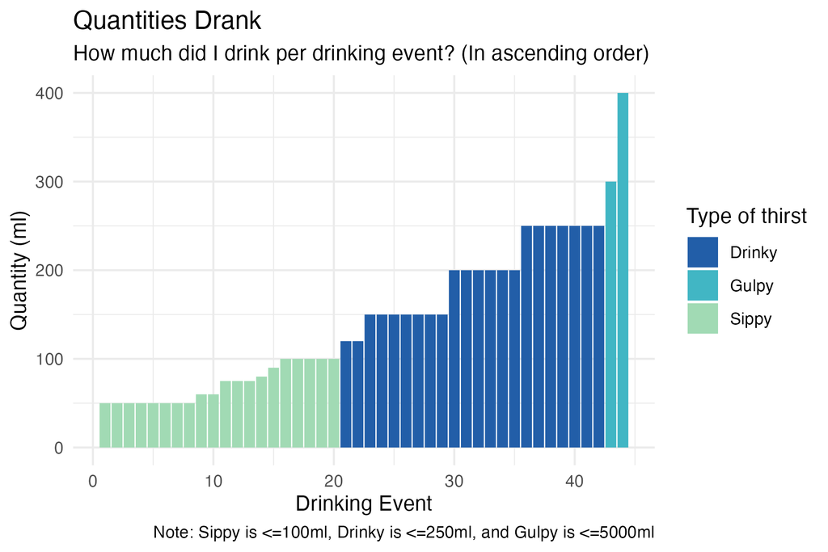

Plot 2: Visualisation of the estimated quantity (in ml) drank per event, in ascending order

This sheds real light on my reasonability. Of course I do not only have one sip! 2l is a lot and that simply wouldn’t do. Likewise, I extraordinarily reasonably maxed out my gulping at a mere 400ml, and it was a glorious gulping, indeed.

The stable steps, especially in the “Drinky” category, belies my tendency to drink fairly standard quantities - one could say I’ve developed a bit of a drinking habit. It also realistically is a consequence of my inability to measure a liquid simply by sipping it - my estimates are perhaps a bit conveniently centred around round numbers.

You now certainly have a much better idea of the quantities I drink than you will ever need to know.

## Part 3: Time For More Sips?

As an aspiring scientist, I formulate more hypotheses than I could ever manage to investigate. But one that I am grateful to have had the chance to look into (and achieve fantastic grades doing so) is **WHEN**? When do I drink these mystery liquids of mine?

(Aside: There’s very little mystery. I’m drinking water. Coffee in the morning, sure, but almost invariably just plain old tap water.)

I endeavoured to discover when I am getting the most of my hydration done in any given day. I hope it’s not in the evenings…

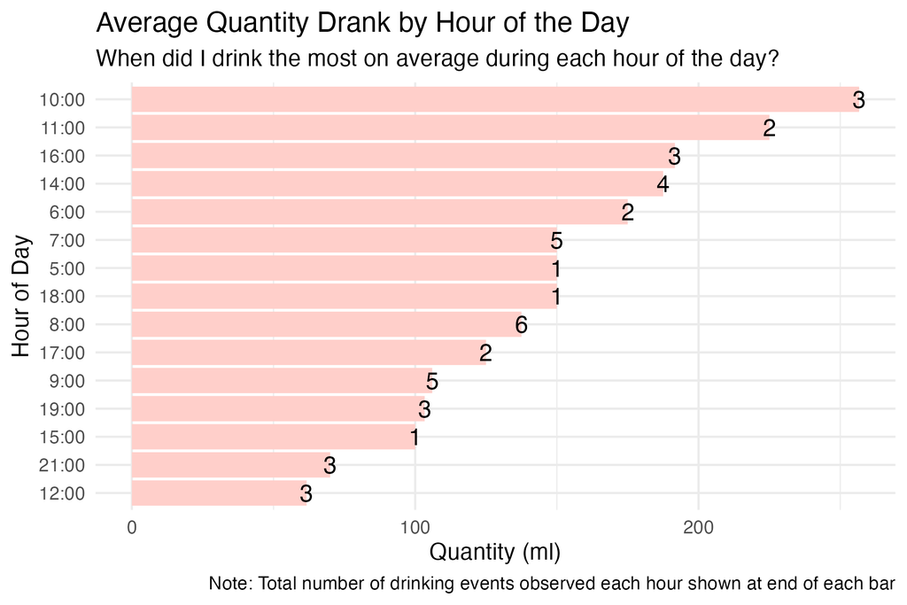

Plot 3: Visualisation of average drank per day, grouped by hour of the day

Well, I am glad to announce that my hopes are well-founded! It appears as though I am at my thirstiest around 10-11AM each day. I totally hypothesised this before creating the plot… totally. A couple hours after my habitual morning coffee, naturally I would be in need of some extra fluids.

Less intuitively for me, I get a second wind (second flow?) in the mid afternoon, but NOT at 3PM. One does not simply drink lots during the median hour of 2-5PM, only from 2-3PM and 4-5PM. Everyone knows this.

Intruigingly, looking at the counts at the end of each bar, I have more drinking events early in the morning, but this can probably be explained by the coffee + water-but-less-water-than-usual-because-I’ve-just-drank-coffee paradigm.

## Conclusion

I am sorry for the inordinate amount of detail you now have into my beverage consumption. I hope it was interesting, but… I have my doubts. Hopefully my needless storytelling antics managed to make talking about drinking water in great detail at all more entertaining for you.